# AB Test: Does Removing Stripe Topup Lead to Fewer MAUs?

Dani Mermelstein

2020-03-29

# Background

On 2020-03-13, we launched an A/B test in the US centered around reducing fraud via Stripe card topups. The alternative hypothesis was that we would be able to reduce AML issues if we simply removed the ability for card topups via Stripe and directed users to do card topup via Google/Apple Pay.

Since we are so early into the test we don’t actually have enough cases of fraud yet to determine whether there has been a reduction of that metric. A concern has also developed around the funding rates observed for the treatment variant: mainly that by removing a funding method we have significantly affected the overall number of users who would fund at all. We therefore will look at first-time funding rates to understand the high-level effects of running this test in its current form.

## Definitions and Notes

- “New” user: someone who signed up after 2020-03-13
- “Tenured” user: someone who signed up before 2020-03-13
- “Google/Apple_Pay”: name of the treatment variant
- “Both_Methods”: name of the control variant
- Valid outcomes are filtered to first-time funding after the test start, ie only first time transactions happening after 2020-03-13 (based on transaction completion date)
- We do not take into account transaction completion rates because this analysis is interested in whether users choose to fund or not

# TL;DR

We want to know how many users we have prevented from becoming ftMAU due to removing the Stripe topup capability.

## Results

Looking at all users in our test shows that **there is no difference in the overall funding rate between the treatment and control variants.** However, there are underlying differences between new and tenured user behavior that counteract each other.

- New users are showing a decrease of 1.81% in their ftMAU rate
  - This is driven by a reduction in Card TopUp transactions, and while we do see an increase in non-card funding it is not enough to cover the deficit.
  - It is possible with the recent launch of Stripe/Plaid ACH (and further funding methods) this impact to new user ftMAU will be reduced if we run the test for longer
- Tenured users show no significant difference between their ftMAU rate.
  - This might hint that users who take longer to fund (but might in their future) are less likely to have a preference for funding through Stripe TopUp vs other methods available.

Because tenured users outnumber new users in our test, they mask how new users are affected by the lack of Stripe TopUp.

## Recommendations and further discussion

- Additional analysis is needed around the downstream financial impact of a 1.81% drop in the ftMAU rate going forward, and what size reduction of fraud would justify that drop.
- We can keep debit card TopUp available but implement zip code matching for fraud reduction.
- New funding methods should continue be explored, since a large percentage of funding users (both new and tenured) did appear to be able to switch away from card-related funding if needed.

## Deep Dive

We chose to look at `card ftMAU` and `overall ftMAU` metrics through three lenses:

1. Overall population
2. New user population
3. Tenured user population

We used a *Test of Equal or Given Proportions* to check whether there are statistically significant differences between funding rates for the control and treatment groups.

### All Users

This rate includes all funding methods, eg Apple Pay, Stripe Topup, external ACH, Stripe/Plaid ACH.

When we look at the test results from this angle, the difference in the overall funding rate is **NOT statistically significant** (p-value = 0.3305)

- Control group funding rate: **13.75%**
- Treatment group funding rate: **14.20%**

We can look a little deeper at two two opposing trends in this test:

1. **A reduction in users funding via debit card**
   - *4.01%* users in control vs *2.25%* users in treatment. This difference is **statistically significant** (p-value = 0)
2. **An increase in users funding via non-card options (ie ACH)**
   - *9.73%* users in control vs *11.95%* users in treatment

The increase in users funding via non-card options has actually fully counterbalanced the decrease in card funding. This would indicate that some users who are currently using Stripe topup are able and willing to use other funding methods, if those methods were more prominent and accessible (or if they had to).

### New Users

This rate includes all funding methods, eg Apple Pay, Stripe Topup, external ACH, Stripe/Plaid ACH.

When we look at the test results from this angle, the difference in the overall funding rate is **NOT statistically significant** (p-value = 0.795)

- Control group funding rate: **21.30%**
- Treatment group funding rate: **20.91%**

We’ve observed two opposing trends so far in this test:

1. **A reduction in users funding via debit card**
   - *8.72%* users in control vs *4.56%* users in treatment. This difference is **statistically significant** (p-value = 0)
2. **An increase in users funding via non-card options (ie ACH)**
   - *12.58%* users in control vs *16.35%* users in treatment

The increase in users funding via non-card options hasn’t been enough to fully counterbalance the decrease in card funding, **resulting in an 1.81% decrease in the ftMAU rate** among new users (from 21.30% down to 20.91%). On the bright side, this would indicate that some new users who are currently using Stripe topup are able and willing to use other funding methods, if those methods were more prominent and accessible (or if they had to).

### Tenured Users

This rate includes all funding methods, eg Apple Pay, Stripe Topup, external ACH, Stripe/Plaid ACH.

When we look at the test results from this angle, the difference in the overll funding rate is **NOT statistically significant** (p-value = 0.1868)

- Control group funding rate: **12.53%**
- Treatment group funding rate: **13.17%**

We’ve observed two opposing trends so far in this test:

1. **A reduction in users funding via debit card**
   - *3.25%* users in control vs *1.89%* users in treatment. This difference is **statistically significant** (p-value = 0)
2. **An increase in users funding via non-card options (ie ACH)**
   - *9.27%* users in control vs *11.27%* users in treatment

The increase in users funding via non-card options has actually fully counterbalanced the decrease in card funding. This would indicate that some users who are currently using Stripe topup are able and willing to use other funding methods, if those methods were more prominent and accessible (or if they had to).

# Analysis Output

## Card Funding Only

### All Users

| variant_name | card_funded | users | card_rate |
| --- | --- | --- | --- |
| BOTH_METHODS | 440 | 10962 | 0.0401387 |
| GOOGLE/APPLE_PAY | 251 | 11161 | 0.0224890 |

```
##
##  2-sample test for equality of proportions without continuity
##  correction
##
## data:  agg$card_funded out of agg$users
## X-squared = 56.933, df = 1, p-value = 4.508e-14
## alternative hypothesis: two.sided
## 95 percent confidence interval:
##  0.01305968 0.02223959
## sample estimates:
##     prop 1     prop 2
## 0.04013866 0.02248902
```

### New Users

| variant_name | card_funded | users | card_rate |
| --- | --- | --- | --- |
| BOTH_METHODS | 133 | 1526 | 0.0871560 |
| GOOGLE/APPLE_PAY | 68 | 1492 | 0.0455764 |

```
##
##  2-sample test for equality of proportions without continuity
##  correction
##
## data:  agg_new$card_funded out of agg_new$users
## X-squared = 20.981, df = 1, p-value = 4.639e-06
## alternative hypothesis: two.sided
## 95 percent confidence interval:
##  0.02390821 0.05925090
## sample estimates:
##     prop 1     prop 2
## 0.08715596 0.04557641
```

### Tenured Users

| variant_name | card_funded | users | card_rate |
| --- | --- | --- | --- |
| BOTH_METHODS | 307 | 9436 | 0.0325350 |
| GOOGLE/APPLE_PAY | 183 | 9669 | 0.0189265 |

```
##
##  2-sample test for equality of proportions without continuity
##  correction
##
## data:  agg_tenured$card_funded out of agg_tenured$users
## X-squared = 35.39, df = 1, p-value = 2.699e-09
## alternative hypothesis: two.sided
## 95 percent confidence interval:
##  0.009115025 0.018101988
## sample estimates:
##     prop 1     prop 2
## 0.03253497 0.01892647
```

## Overall Funding

### All Users

| variant_name | total_funded | users | overall_rate |
| --- | --- | --- | --- |
| BOTH_METHODS | 1507 | 10962 | 0.1374749 |
| GOOGLE/APPLE_PAY | 1585 | 11161 | 0.1420124 |

```
##
##  2-sample test for equality of proportions without continuity
##  correction
##
## data:  agg$total_funded out of agg$users
## X-squared = 0.94702, df = 1, p-value = 0.3305
## alternative hypothesis: two.sided
## 95 percent confidence interval:
##  -0.013674748  0.004599846
## sample estimates:
##    prop 1    prop 2
## 0.1374749 0.1420124
```

### New Users

| variant_name | total_funded | users | overall_rate |
| --- | --- | --- | --- |
| BOTH_METHODS | 325 | 1526 | 0.2129751 |
| GOOGLE/APPLE_PAY | 312 | 1492 | 0.2091153 |

```
##
##  2-sample test for equality of proportions without continuity
##  correction
##
## data:  agg_new$total_funded out of agg_new$users
## X-squared = 0.067496, df = 1, p-value = 0.795
## alternative hypothesis: two.sided
## 95 percent confidence interval:
##  -0.02525664  0.03297628
## sample estimates:
##    prop 1    prop 2
## 0.2129751 0.2091153
```

### Tenured Users

| variant_name | total_funded | users | overall_rate |
| --- | --- | --- | --- |
| BOTH_METHODS | 1182 | 9436 | 0.1252649 |
| GOOGLE/APPLE_PAY | 1273 | 9669 | 0.1316579 |

```
##
##  2-sample test for equality of proportions without continuity
##  correction
##
## data:  agg_tenured$total_funded out of agg_tenured$users
## X-squared = 1.7428, df = 1, p-value = 0.1868
## alternative hypothesis: two.sided
## 95 percent confidence interval:
##  -0.015881279  0.003095413
## sample estimates:
##    prop 1    prop 2
## 0.1252649 0.1316579
```

# Difference by Days from Signup

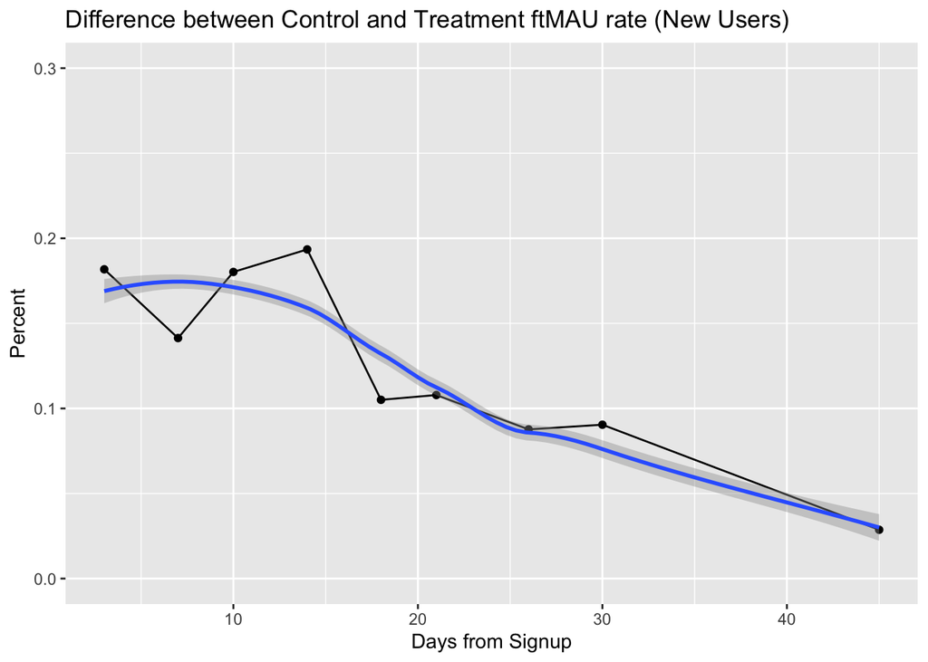

# Bayesian Analysis

## All Users

estimated lift: 3%

### Plots

| Variants | Users | Outcomes | Rate |
| --- | --- | --- | --- |
| control | 10962 | 1507 | 0.1374749 |
| treatment | 11161 | 1585 | 0.1420124 |

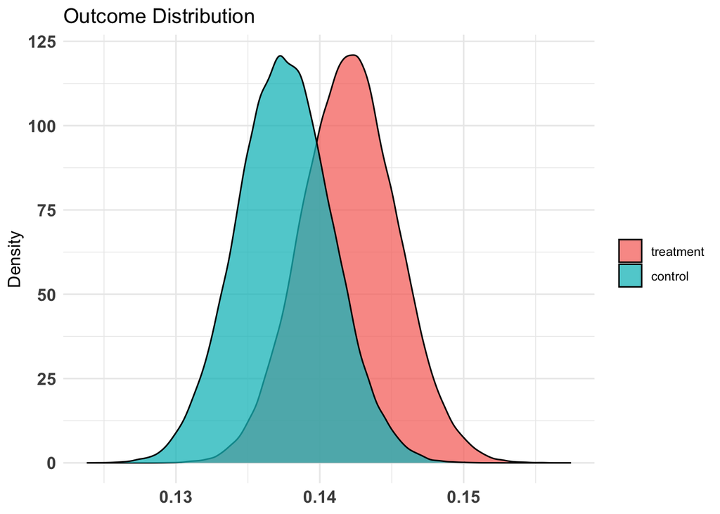

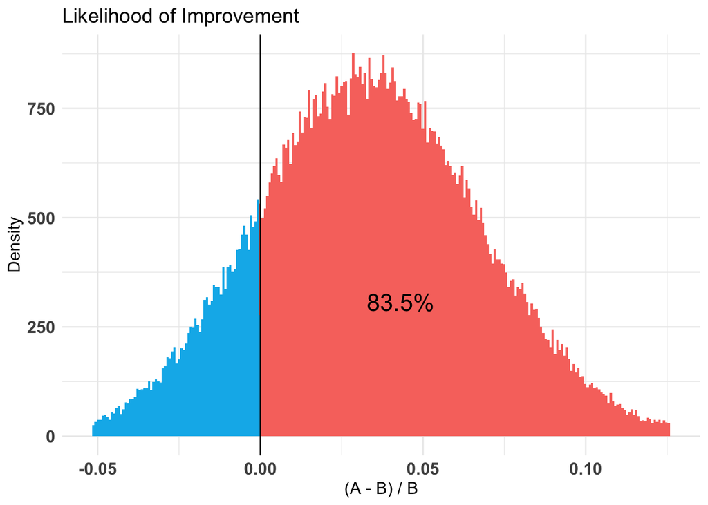

```
## Quantiles of posteriors for A and B:
##
## $Probability
## $Probability$A
##        0%       25%       50%       75%      100%
## 0.1288175 0.1398358 0.1420695 0.1442829 0.1574177
##
## $Probability$B
##        0%       25%       50%       75%      100%
## 0.1238459 0.1353091 0.1375112 0.1397400 0.1522213
##
##
## --------------------------------------------
##
## P(A > B) by (0)%:
##
## $Probability
## [1] 0.83512
##
## --------------------------------------------
##
## Credible Interval on (A - B) / B for interval length(s) (0.9) :
##
## $Probability
##          5%         95%
## -0.02213059  0.09111752
##
## --------------------------------------------
##
## Posterior Expected Loss for choosing B over A:
##
## $Probability
## [1] 0.002967367
```

## New Users (all-time)

estimated lift: -1%

### Plots

| Variants | Users | Outcomes | Rate |
| --- | --- | --- | --- |
| control | 1526 | 325 | 0.2129751 |
| treatment | 1492 | 312 | 0.2091153 |

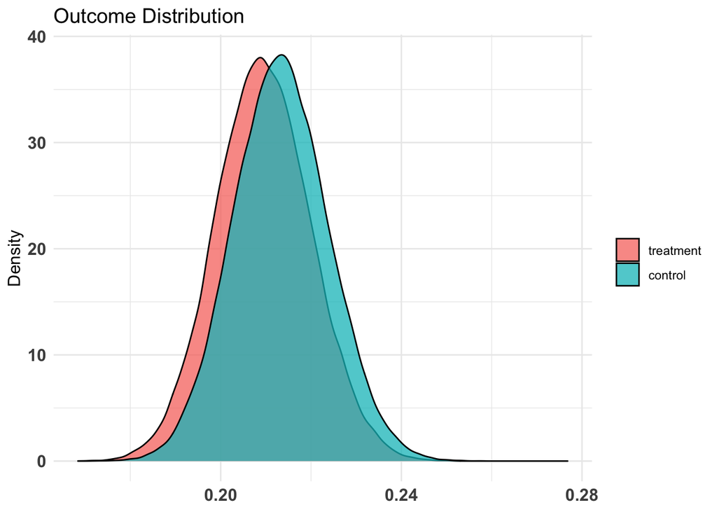

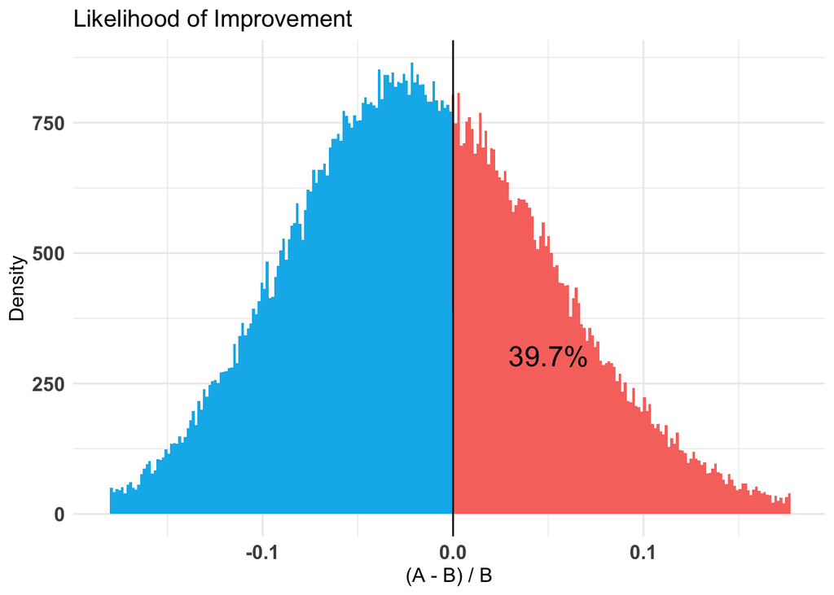

```
## Quantiles of posteriors for A and B:
##
## $Probability
## $Probability$A
##        0%       25%       50%       75%      100%
## 0.1684053 0.2022981 0.2093344 0.2164872 0.2571743
##
## $Probability$B
##        0%       25%       50%       75%      100%
## 0.1711861 0.2061869 0.2132369 0.2203465 0.2768067
##
##
## --------------------------------------------
##
## P(A > B) by (0)%:
##
## $Probability
## [1] 0.39708
##
## --------------------------------------------
##
## Credible Interval on (A - B) / B for interval length(s) (0.9) :
##
## $Probability
##         5%        95%
## -0.1260087  0.1023642
##
## --------------------------------------------
##
## Posterior Expected Loss for choosing B over A:
##
## $Probability
## [1] 0.04027143
```

## New Users (within 30 days)

### Plots

| Variants | Users | Outcomes | Rate |
| --- | --- | --- | --- |
| control | 1526 | 271 | 0.1775885 |
| treatment | 1492 | 241 | 0.1615282 |

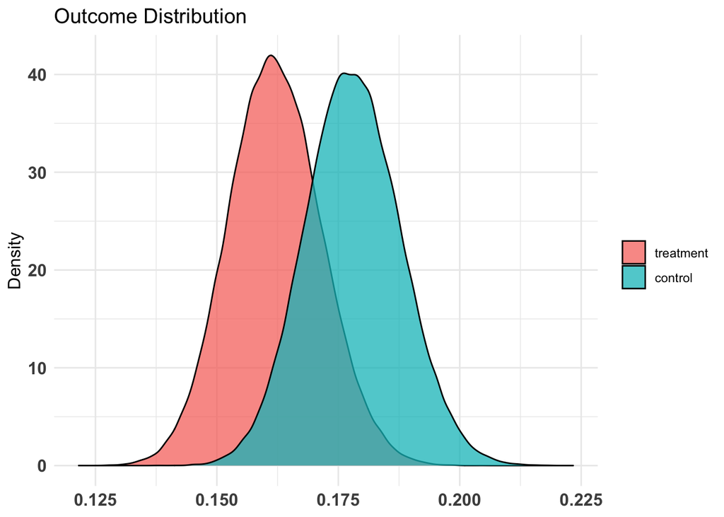

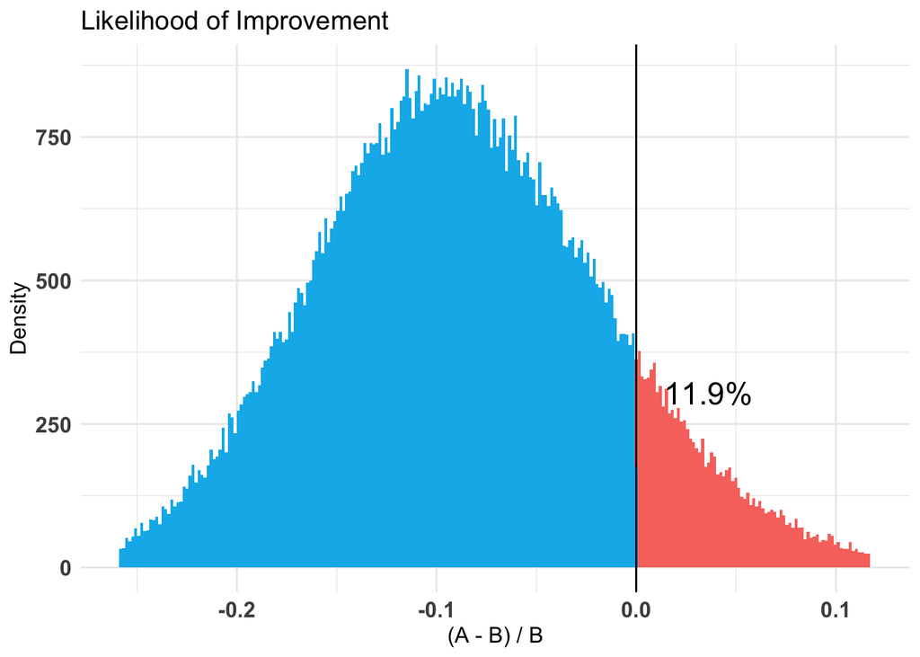

```
## Quantiles of posteriors for A and B:
##
## $Probability
## $Probability$A
##        0%       25%       50%       75%      100%
## 0.1215609 0.1554603 0.1618064 0.1683138 0.2049415
##
## $Probability$B
##        0%       25%       50%       75%      100%
## 0.1320221 0.1713787 0.1779108 0.1846160 0.2233399
##
##
## --------------------------------------------
##
## P(A > B) by (0)%:
##
## $Probability
## [1] 0.11894
##
## --------------------------------------------
##
## Credible Interval on (A - B) / B for interval length(s) (0.9) :
##
## $Probability
##          5%         95%
## -0.20349073  0.03810841
##
## --------------------------------------------
##
## Posterior Expected Loss for choosing B over A:
##
## $Probability
## [1] 0.1075807
```

## All User Disputes (all-time)

### Plots

| Variants | Users | Outcomes | Rate |
| --- | --- | --- | --- |
| control | 10962 | 3 | 0.0002737 |
| treatment | 11161 | 2 | 0.0001792 |

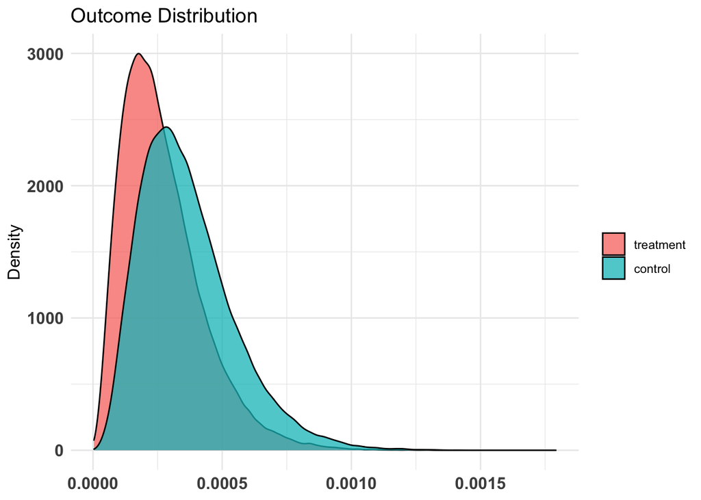

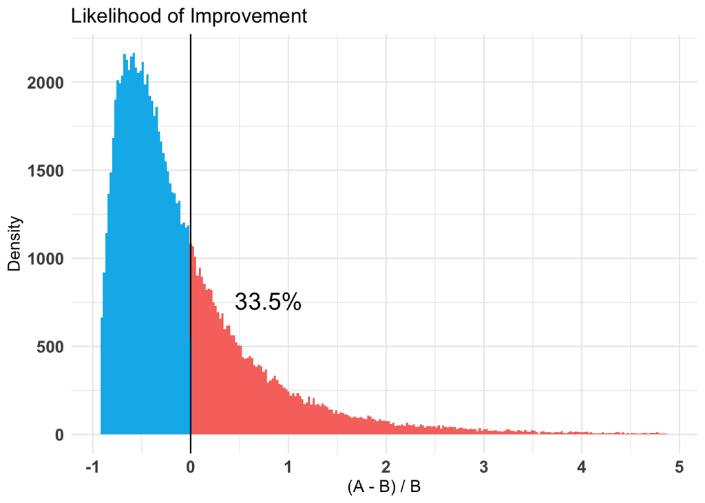

```
## Quantiles of posteriors for A and B:
##
## $Probability
## $Probability$A
##           0%          25%          50%          75%         100%
## 3.657867e-06 1.541553e-04 2.388264e-04 3.506635e-04 1.634703e-03
##
## $Probability$B
##           0%          25%          50%          75%         100%
## 1.707723e-05 2.312789e-04 3.352418e-04 4.653243e-04 1.791128e-03
##
##
## --------------------------------------------
##
## P(A > B) by (0)%:
##
## $Probability
## [1] 0.33473
##
## --------------------------------------------
##
## Credible Interval on (A - B) / B for interval length(s) (0.9) :
##
## $Probability
##         5%        95%
## -0.8234351  1.6206619
##
## --------------------------------------------
##
## Posterior Expected Loss for choosing B over A:
##
## $Probability
## [1] 1.164213
```

# Deposit Amounts

## Tenured Users

```
##
##  Wilcoxon rank sum test with continuity correction
##
## data:  control and treatment
## W = 748195, p-value = 0.813
## alternative hypothesis: true location shift is not equal to 0
```

Average deposit amounts:

- Control: $211.97
- Treatment: $232.70

Median deposit amounts:

- Control: $50
- Treatment: $50

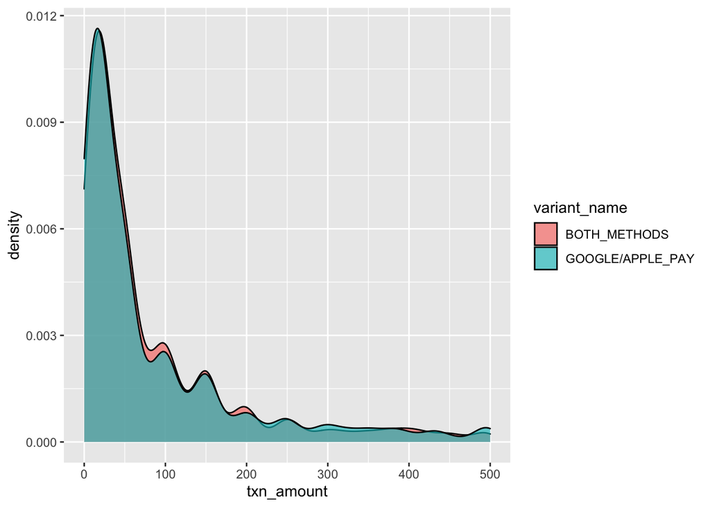

## New Users

```
##
##  Wilcoxon rank sum test with continuity correction
##
## data:  control and treatment
## W = 51629, p-value = 0.6887
## alternative hypothesis: true location shift is not equal to 0
```

Average deposit amounts:

- Control: $142.35
- Treatment: $174.44

Median deposit amounts:

- Control: $50
- Treatment: $44

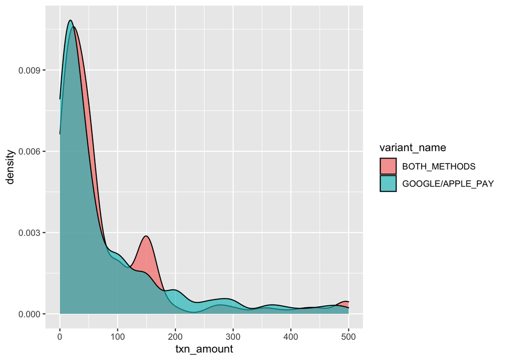

# Stripe Radar Risk Scores

```
##                  variant  avg_risk
## 1:          Both methods 11.440098
## 2: Google/Apple pay only  4.061269
```